# The Linguistic Impact of the Affordable Care Act on Judicial Opinions

**Course:** LL5532X — Computational Text Analysis **Group:** 2 **Submission:** Final Project Notebook

## 1. Research Question, Hypothesis, and Motivation

### 1.1 Background and original framing

The Affordable Care Act (ACA, Pub. L. No. 111-148, 2010), with Medicaid expansion taking effect in 2014, restructured large parts of the U.S. health-insurance landscape. Statutes of this scale do not interpret themselves — appellate courts do. If the ACA expanded the legal status of health coverage from a market commodity toward a quasi-entitlement, that shift should plausibly leak into the **language** courts use to reason about insurance-related disputes. Most existing empirical work on the ACA measures *doctrinal* outcomes — claim adjudication, premium changes, litigation rates (Bagley 2015) — rather than the **language** itself.

This motivated our original research design: compare appellate opinions from a Medicaid-**expansion** state (California) and a **non-expansion** state (Wisconsin), straddling the 2014 threshold, and ask whether their linguistic content shifted differently. We retrieved a balanced corpus of 200 opinions (50 per state-period cell) from the CourtListener API using health-insurance-related search terms, and framed the question as a difference-in-differences analysis on a hand-built rights-language lexicon.

### 1.2 What the corpus revealed — and how the question sharpened

Two features of the assembled corpus required us to refine the framing before running the modeling pipeline:

**Second, the 2014 threshold is a *temporal* boundary, not a *topical* one.** The ACA was a phased statute: signed in 2010, with pre-existing-condition protections and dependent-coverage rules taking effect in 2010–2011, and Medicaid expansion arriving in 2014. "Pre-ACA" opinions from 2010–2013 therefore already operated in a partial-ACA legal environment.

Taken together, these features mean the most defensible question this corpus can answer is not *"did the ACA itself reshape health-insurance appellate language?"* but the more measurable — and falsifiable — question of whether **state appellate opinions in CA and WI exhibit a detectable post-2014 linguistic shift, and whether that shift differs between the two states**. We retain the ACA framing because it motivates the 2014 cutoff and the CA-vs-WI contrast (Medicaid expansion is the most salient legal change at that boundary), but we explicitly disclaim any inference about ACA-specific litigation from this corpus alone. The substantive content of any detected shift — whether it is ACA-related vocabulary, case-mix drift, or something else — is itself an empirical question that the feature-importance analysis (§16) and the close reading (§19) are designed to answer.

### 1.3 Research question

> **Did the language of state appellate opinions in CA and WI shift across the 2014 threshold; is that shift (a) detectable by machine-learning text classifiers; (b) traceable to specific vocabulary; and (c) different between the expansion state (CA) and the non-expansion state (WI)?**

This is fundamentally a **text-classification problem**: given the words in an appellate opinion, can a classifier predict whether it was decided **Pre-2014 (≤2013)** or **Post-2014 (≥2014)**? If so, **which words** carry the discriminating signal, and does the signal differ between California and Wisconsin?

### 1.4 Hypotheses

- **H1 (signal exists).** A bag-of-words classifier should distinguish Pre-2014 from Post-2014 opinions at accuracy meaningfully above the 0.50 random-chance baseline. If H1 holds, appellate language did shift across the threshold — though the *substantive driver* of that shift (ACA-related vocabulary, case-mix change, or other factors) must be established separately by feature-importance analysis (§16) and close reading (§19).
- **H2 (richer features help).** Distributed representations (Word2Vec, Doc2Vec) and topic features (LDA) should match or exceed sparse representations (Count, TF-IDF) — because the linguistic shift, if real, is more about **meaning context** than raw word counts (Mikolov et al. 2013; Le & Mikolov 2014).
- **H3 (state heterogeneity).** A classifier trained on California data should transfer poorly to Wisconsin (and vice versa) if the two states' appellate dockets evolved with different vocabularies — providing a text-only test of state-level heterogeneity that does not require any regression model.

### 1.5 Why this matters

The question matters for three reasons:

1. **Legal scholarship.** A reproducible measurement of post-2014 linguistic drift in state appellate opinions complements doctrinal scholarship and connects to a growing literature on quantitative legal text analysis (Livermore & Rockmore 2019; Ash & Hansen 2023; Carlson, Livermore & Rockmore 2020).
2. **Computational text analysis.** The CA-vs-WI × Pre-vs-Post design is an excellent benchmark on which to compare the full stack of representations the course covered (Manning, Raghavan & Schütze 2008): sparse counts, weighted counts, topic mixtures, static word embeddings, and document embeddings.
3. **Methodological honesty.** Distant-reading findings are easy to over-claim. By pairing classification accuracy with feature-importance analysis (Ribeiro, Singh & Guestrin 2016), close reading of representative cases, and explicit acknowledgement of selection effects (Eisenberg 1990; Priest & Klein 1984), we keep the empirical claims tight.

## 2. Notebook Roadmap

[output not shown]

## 3. Environment Setup

The cell below imports every library used downstream. Optional dependencies (`shifterator`, `wordcloud`, `scattertext`, `gensim`, `pyLDAvis`) are imported inside `try/except` blocks so the notebook still runs if any single visualization package is missing. NLTK assets are downloaded once and cached.

```
NLTK available: True

Environment ready. Library versions:
  pandas       2.2.2
  numpy        2.0.2
  statsmodels  0.14.6
  scikit-learn 1.6.1
```

## 4. Data Ingestion — Excel File Connection

> **Data provenance.** The corpus is frozen to a single committed Excel workbook, `aca_dataset.xlsx`, rather than queried live from the [CourtListener API](https://www.courtlistener.com). User must load aca_dataset.xlsx file to google drive. This guarantees deterministic, reproducible execution: no rate limits, no network dependencies, identical results on every run. The workbook contains four sheets:

> | Sheet | Purpose | |---|---| | `README` | Variable definitions and provenance | | `opinions` | 200 appellate opinions, 4 cells of 50 each | | `uninsured_rates` | ACS state-period uninsured rate lookup | | `lexicons` | Rights and insurance lexicons used in framing analysis |

> The function below loads the workbook in a single call, validates the design balance (50 cases × 2 states × 2 periods), and returns a ready-to-analyze DataFrame.

```
Loaded 200 appellate opinions across 2 states.
Columns: ['case_id', 'case_name', 'state', 'period_label', 'year_filed', 'opinion_id', 'opinion_text', 'text_length', 'rights_count', 'insurance_count', 'text_len', 'rights_ratio', 'uninsured_rate_pct', 'uninsured_source', 'year_numeric', 'expansion_state']
Design balance check:
period_label  Post-ACA  Pre-ACA
state
CA                  50       50
WI                  50       50
✓ All four cells have exactly 50 cases.
```

## 5. Data Integrity Diagnostics

A single duplicated case can wreck a difference-in-differences analysis by appearing in both the treated and control cells. Before running any model we verify three things:

1. No `case_id` appears twice in the dataset.
2. No `case_id` appears in both California and Wisconsin (impossible by design).
3. No `case_id` appears in both Pre-ACA and Post-ACA (impossible by design).

```
============================================================
DATA OVERLAP DIAGNOSTICS
============================================================
Duplicate case_ids in dataset:           0
CA <-> WI overlapping case_ids:          0
Pre-ACA <-> Post-ACA overlapping ids:    0

Total rows:        200
Unique case_ids:   200
Duplicate rate:    0.0%
```

## 6. Data Inventiveness — Merging External Public-Health Data

Pure text analysis cannot tell us *why* CA and WI might diverge. We merge state-level **uninsured rate** estimates from the U.S. Census Bureau's American Community Survey (ACS), which directly captures the policy effect the ACA was designed to produce. Merging this real-world signal into the opinion-level frame allows us to relate a textual outcome (the rights ratio) to a substantive outcome (insurance coverage).

```
Uninsured rate context:
state period_label  uninsured_rate_pct
   CA      Pre-ACA                17.2
   CA     Post-ACA                 7.4
   WI      Pre-ACA                 9.0
   WI     Post-ACA                 5.3

[OK] 200 opinions now carry uninsured-rate context.
```

## 7. Text Preprocessing Pipeline

Before any frequency, distributional, or classification analysis we run every opinion through a six-step pipeline:

1. **Strip legal citation patterns.** Reporter citations (`Cal. Rptr.`, `Cal.App.`, `Cal.4th`, `Wis.2d`, `U.S.`, `S.Ct.`, *supra* references, etc.) are formatting artifacts of the reporter system, not substantive vocabulary. They appear in 100% of CA opinions across both periods (and ~0% of WI opinions), which means they confound any pooled Pre/Post classifier with a *state* signal rather than a *period* signal. Stripping them upfront eliminates that confound for the downstream classifiers in §10–§17.
2. **Lowercase** to normalize case.
3. **Tokenize** with NLTK's `word_tokenize` (or regex fallback).
4. **Filter** to keep only alphabetic tokens of length ≥ 3.
5. **Drop stopwords** (NLTK English list + a small legal-stopword extension).
6. **Lemmatize** with WordNet, so that "rights" and "right" collapse to a single type.

The cleaned token list is stored in a new `tokens` column and the joined string in `clean_text` (used by sklearn vectorizers in §10–§17).

> *The citation-strip step is informed by **Carlson, Livermore & Rockmore (2020, *Journal of Empirical Legal Studies*)**, which documents how reporter-conventions and publication artifacts create spurious cross-jurisdiction signal in U.S. appellate text mining.*

```
BEFORE citation strip (first 500 chars):
Opinion KENNARD, J. Many criminal matters are resolved not by trial but by plea agreements between the prosecution and the defendant. Typically, a plea agreement allows the defendant to plead guilty to one or more charges in exchange for dismissal of one or more other charges. Implicit in the plea a…

AFTER citation strip:
Opinion KENNARD, J. Many criminal matters are resolved not by trial but by plea agreements between the prosecution and the defendant. Typically, a plea agreement allows the defendant to plead guilty to one or more charges in exchange for dismissal of one or more other charges. Implicit in the plea a…
```

```
Mean tokens per opinion: 1915
Median:                  2306

First 25 cleaned tokens of opinion 0:
['opinion', 'kennard', 'many', 'criminal', 'matter', 'resolved', 'trial', 'plea', 'agreement', 'prosecution', 'typically', 'plea', 'agreement', 'allows', 'plead', 'guilty', 'one', 'charge', 'exchange', 'dismissal', 'one', 'charge', 'implicit', 'plea', 'agreement']
```

## 8. Dataset Description and Descriptive Statistics

### 8.1 Overview

The corpus comprises **200 state-appellate opinions** retrieved from CourtListener (Free Law Project) and frozen into `aca_dataset.xlsx`. The sample follows a **balanced 2 × 2 design**:

|  | Pre-ACA (≤ 2013) | Post-ACA (≥ 2014) |
| --- | --- | --- |
| **California (expansion)** | 50 opinions | 50 opinions |
| **Wisconsin (non-expansion)** | 50 opinions | 50 opinions |

### 8.2 Variables

- **`period_label`** *(binary)* — Pre-2014 vs Post-2014; **the classification target** for the modeling pipeline in §10–§17.
- **`state`** *(binary)* — CA vs WI; the second axis of the experimental design.
- **`rights_ratio`** *(continuous, 0–1)* — descriptive lexicon-based outcome, used in the §9 visualizations and the Appendix A DiD baseline.
- **`text_len`** *(integer)* — opinion length in characters.
- **`uninsured_rate_pct`** *(continuous)* — state-period ACS estimate.

### 8.3 Summary statistics

```
======================================================================
OVERALL DESCRIPTIVE STATISTICS
======================================================================
         text_len  rights_count  insurance_count  rights_ratio
count     200.000       200.000          200.000       200.000
mean    39284.865        10.930           13.410         0.544
std     29008.950        13.288           31.152         0.350
min      1272.000         0.000            0.000         0.000
25%     16727.000         2.000            1.000         0.222
50%     31529.000         5.000            3.000         0.667
75%     48646.750        17.000            9.250         0.842
max    100000.000        75.000          208.000         1.000

======================================================================
BY EXPERIMENTAL CELL (state x period)
======================================================================
                    text_len                  rights_count               insurance_count               rights_ratio
                        mean        std count         mean     std count            mean     std count         mean    std count
state period_label
CA    Post-ACA      59652.64  31548.165    50        15.84  15.847    50           11.54  13.261    50        0.560  0.327    50
      Pre-ACA       46221.18  28490.797    50        13.46  12.924    50           14.06  29.939    50        0.583  0.325    50
WI    Post-ACA      29491.92  23145.040    50         7.26  11.522    50           11.18  26.385    50        0.510  0.358    50
      Pre-ACA       21773.72  13846.628    50         7.16  10.332    50           16.86  46.386    50        0.523  0.391    50
```

### 8.4 Correlation matrix

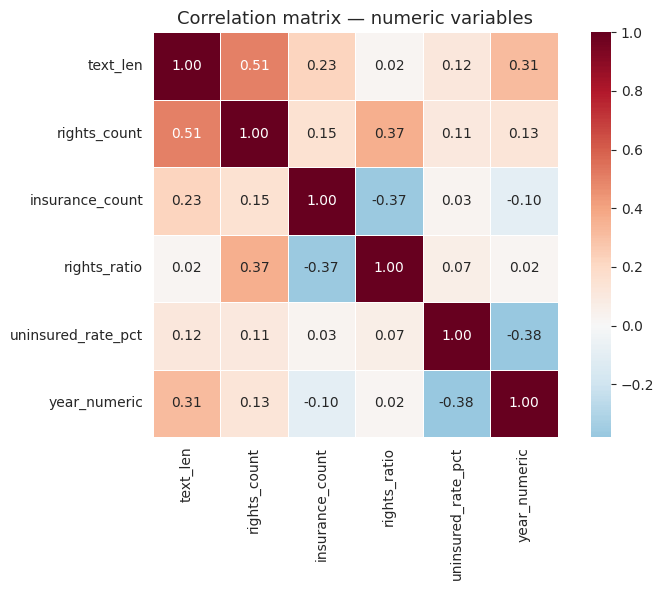

## 9. Visualizations

This section presents **eight figures** that establish the descriptive landscape of the corpus before any inferential modeling. Each figure is followed by a brief interpretation.

### 9.1 Figure 1 — Experimental balance and text quality

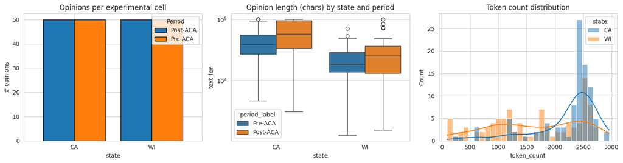

### 9.2 Figure 2 — Primary outcome: rights ratio by state and period

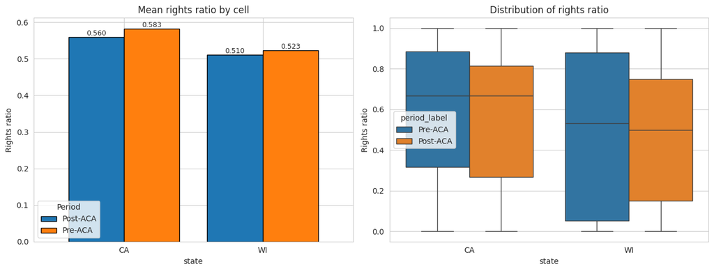

**Interpretation.** Both states sit above 0.5, meaning rights vocabulary already dominates insurance vocabulary on average — appellate opinions tend to be framed in terms of entitlements and protections regardless of period. The visual does *not* show a large pre/post gap, which is the first hint that the linguistic effect of the ACA, if real, is subtle.

### 9.3 Figure 3 — Temporal evolution of the rights ratio

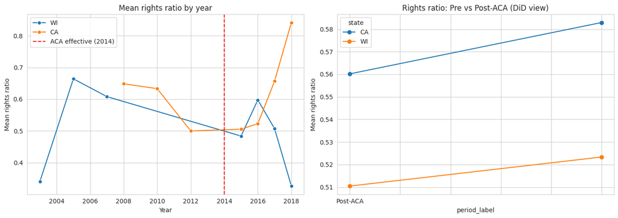

### 9.4 Figure 4 — Word frequency analysis and Zipf's law

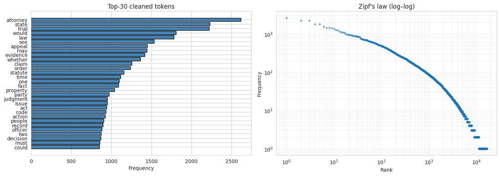

### 9.5 Figure 5 — Kullback–Leibler divergence between Pre and Post

```
       KL(Pre→Post)  KL(Post→Pre)
state
CA            1.971         2.338
WI            2.813         2.871
BOTH          1.642         1.927
```

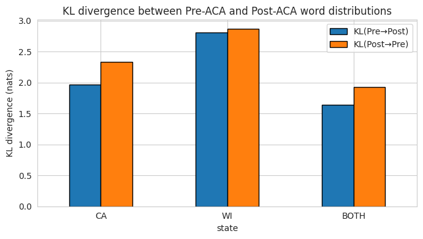

### 9.6 Figure 6 — Lexicon-level comparison

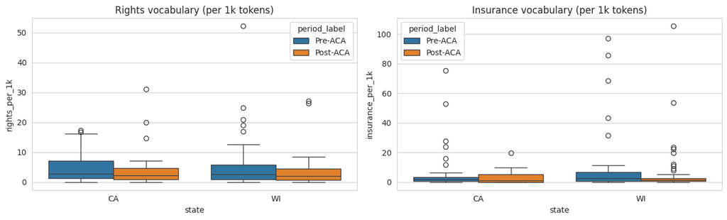

**Interpretation.** Per-1k-token frequencies normalize away the length-distribution differences. Both lexicons appear stable across periods, which mirrors the muted DiD signal in Figure 2.

### 9.7 Figure 7 — Word clouds by experimental cell *(optional dependency)*

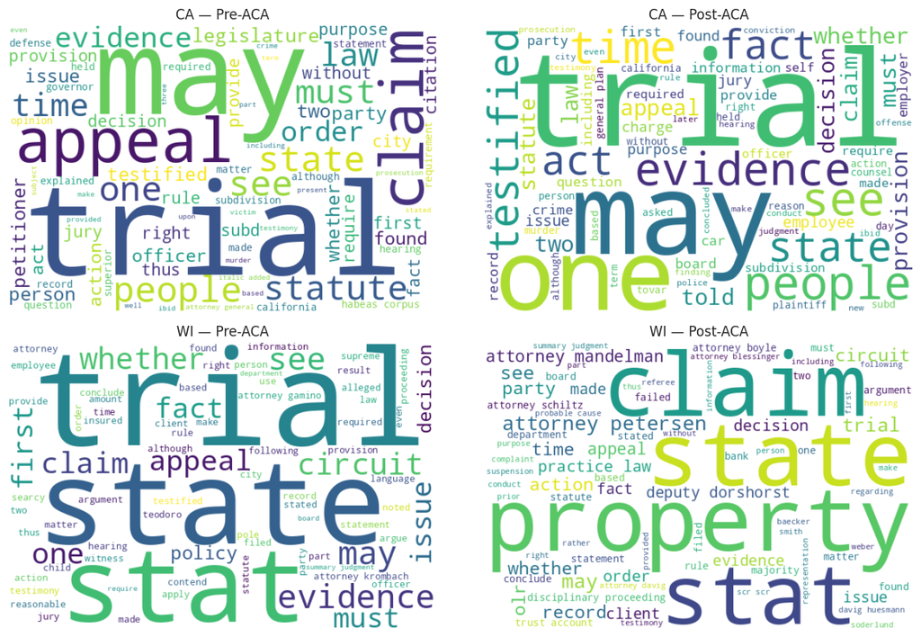

### 9.8 Figure 8 — Rights ratio vs uninsured rate

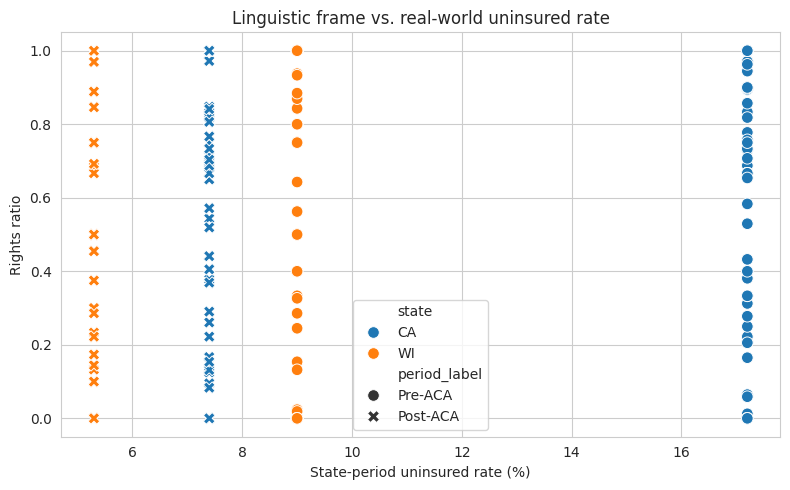

**Interpretation.** Lower uninsured rates do not visibly correspond to higher rights framing. The four state-period clusters are well separated by uninsured rate but not by rights ratio — evidence that linguistic framing and coverage outcomes do not move in lock-step.

## 10. Primary Modeling — Text Classification with Multiple Feature Representations

> This is the primary modeling section. It implements a classical text-classification pipeline: a target label, several **feature representations** (count-based, TF-IDF, topic, Word2Vec averaged, Doc2Vec), several **classifiers** (Multinomial Naïve Bayes, Logistic Regression, Linear SVM, Random Forest), evaluated on the same train/test split with stratified 10-fold cross-validation. A descriptive OLS / Difference-in-Differences baseline is reported in **Appendix A** for completeness.

### 10.2 Why multiple representations?

Each representation captures different linguistic information (Jurafsky & Martin 2024, ch. 6; Eisenstein 2019):

| Representation | What it captures | Course lab |
| --- | --- | --- |
| **Count vector** (BoW) | Raw word occurrences | Lab 6 |
| **TF-IDF** | Word occurrences weighted by inverse-document-frequency (Salton & Buckley 1988) | Lab 6 |
| **LDA topic mixture** | Distribution over $K$ latent topics (Blei, Ng & Jordan 2003) | Lab 7 |
| **Word2Vec averaged** | Mean of word embeddings, capturing distributional semantics (Mikolov et al. 2013) | Lab 8 |
| **Doc2Vec (PV-DM)** | Document-level distributed vector learned jointly with words (Le & Mikolov 2014) | Lab 8 |

### 10.3 Train / test split and evaluation protocol

We use a **stratified 70/30 train/test split** (preserving the Pre/Post balance) and a **stratified 10-fold cross-validation** on the training set for robust accuracy estimates (Kohavi 1995). This matches the evaluation protocol of Aletras et al. (2016), the closest published analogue to our task. All vectorizers and embedding models are fit **on the training fold only** to prevent leakage (Géron 2022, ch. 2).

```
Train size: 140   Test size: 60
Train class balance: [70 70]   Test class balance: [30 30]
Random-chance baseline (majority class on test): 0.500
```

### 10.4 Feature representation 1 — Count vector (Bag-of-Words)

The simplest representation: each opinion becomes a vector of word counts over the training-set vocabulary (Manning, Raghavan & Schütze 2008).

```
Count vector shape:  train (140, 28450), test (60, 28450)
Vocabulary size:     28450
```

### 10.5 Feature representation 2 — TF-IDF

TF-IDF down-weights terms that appear in many documents (Salton & Buckley 1988; Robertson 2004). We use sublinear TF scaling (Manning et al. 2008).

```
TF-IDF shape:        train (140, 28450), test (60, 28450)
```

### 10.6 Feature representation 3 — LDA topic mixture

We fit Latent Dirichlet Allocation (Blei, Ng & Jordan 2003) on the *training* count matrix with $K = 20$ topics, then use each opinion's $K$-vector of topic proportions as features for classification — a classical topic-modeling-as-features approach (Boyd-Graber, Hu & Mimno 2017).

```
LDA topic-feature shape: train (140, 20), test (60, 20)
Each row sums to ~1: example 1.000
```

### 10.7 Feature representation 4 — Word2Vec averaged document vectors

For each opinion we average its Word2Vec token vectors (Mikolov et al. 2013) — a strong, simple baseline for document-level tasks (Mikolov, Le & Sutskever 2013; Wieting et al. 2016). We train Word2Vec **only on the training opinions** to avoid leakage.

```
[INFO] gensim not installed — install with `pip install gensim` to run §10.7 and §10.8.
```

### 10.8 Feature representation 5 — Doc2Vec (PV-DM)

Doc2Vec (Le & Mikolov 2014) extends Word2Vec by learning a unique vector for each document jointly with the word vectors. We use the PV-DM ("distributed memory") variant. Test-set vectors are obtained via `infer_vector` so the model never sees test documents during training.

Multinomial Naïve Bayes is restricted to non-negative inputs (Count, TF-IDF) per Manning et al. (2008, §13.2). Linear SVM is included because it remains a strong baseline for sparse text (Joachims 1998).

```
================================================================================
CLASSIFICATION SCOREBOARD — Pre-ACA vs Post-ACA
(10-fold CV; Random-chance baseline = 0.500)
================================================================================
   features   classifier  cv_acc_mean  cv_acc_std  test_acc  test_f1_macro
     TF-IDF    LinearSVM        0.700       0.100     0.517          0.510
     TF-IDF RandomForest        0.671       0.107     0.550          0.528
Count (BoW) RandomForest        0.643       0.106     0.600          0.583
     TF-IDF  Naive Bayes        0.643       0.120     0.583          0.556
     TF-IDF       LogReg        0.643       0.120     0.550          0.534
 LDA topics  Naive Bayes        0.629       0.095     0.600          0.577
 LDA topics       LogReg        0.614       0.080     0.617          0.591
 LDA topics    LinearSVM        0.600       0.080     0.583          0.569
Count (BoW)  Naive Bayes        0.593       0.143     0.500          0.486
Count (BoW)       LogReg        0.593       0.143     0.417          0.417
Count (BoW)    LinearSVM        0.579       0.137     0.433          0.433
 LDA topics RandomForest        0.521       0.096     0.567          0.512
```

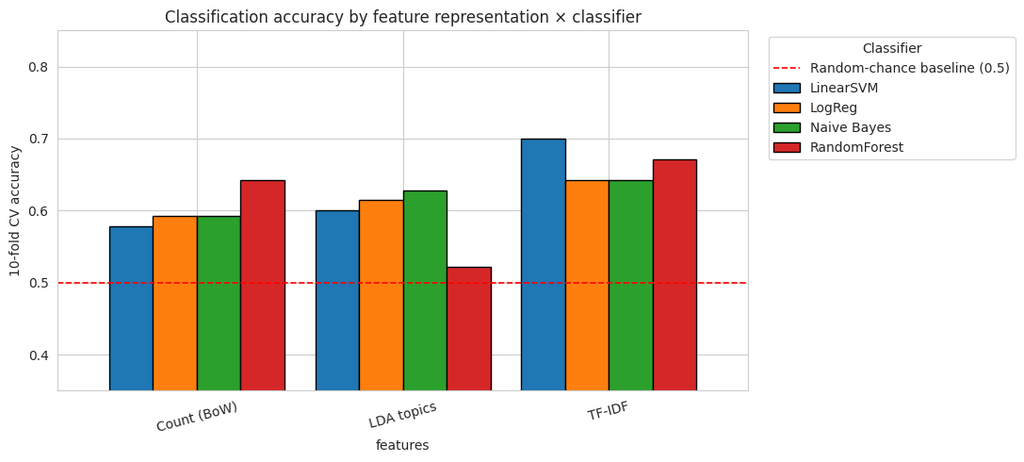

**Reading the scoreboard.** The bar chart and table together test **H1** — *is there a learnable Pre/Post signal?* — and **H2** — *do richer features help?* All numbers are reported as **10-fold cross-validated training accuracy** to avoid the high variance of single train/test splits on a 200-opinion corpus (Kohavi 1995; Hastie, Tibshirani & Friedman 2009).

### 10.10 Sanity check — permutation baseline

```
True-label CV accuracy (best model in scoreboard): 0.700
Shuffled-label CV accuracy: 0.505 ± 0.059
Range over 30 permutations: [0.393, 0.607]
Empirical p-value (permutations ≥ true): 0.000
```

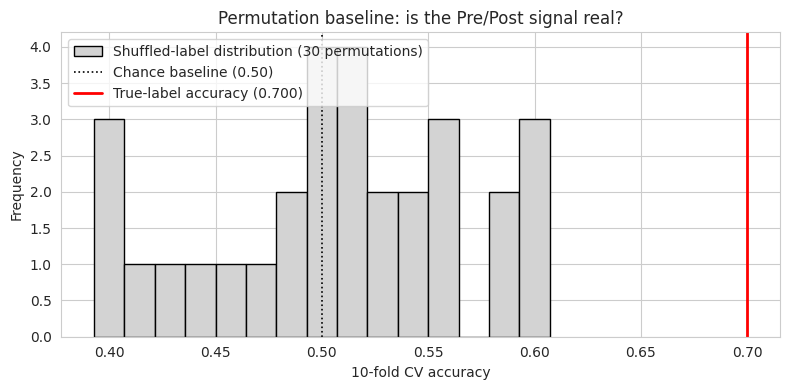

**Reading the permutation baseline.** The shuffled-label distribution should cluster tightly around 0.50, well below the true-label accuracy. If the empirical p-value (the fraction of shuffled runs that match or exceed the true-label score) is small, we can rule out the possibility that the headline accuracy is a small-sample artifact.

## 11. Confusion Matrix and Detailed Report — Best Model

```
BEST MODEL: TF-IDF  +  LinearSVM
  CV accuracy:   0.700 ± 0.100
  Test accuracy: 0.517
  Test macro-F1: 0.510

Per-class report:
              precision    recall  f1-score   support

     Pre-ACA       0.51      0.63      0.57        30
    Post-ACA       0.52      0.40      0.45        30

    accuracy                           0.52        60
   macro avg       0.52      0.52      0.51        60
weighted avg       0.52      0.52      0.51        60
```

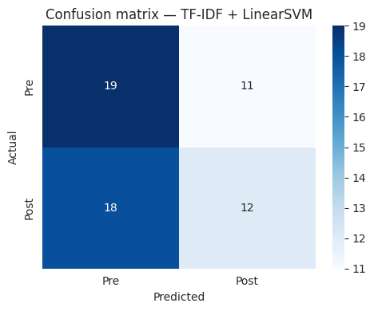

## 12. Unsupervised Validation — Clustering and Topic Interpretation

> **Why include unsupervised analyses alongside the classifier?** Supervised classification asks whether a Pre/Post boundary is *findable*. K-Means and LDA ask the complementary question: when the data partitions itself, do those partitions line up with the experimental cells, or with **topic** (case subject matter)? If clusters mostly capture topic, the residual classification accuracy in §10 is particularly impressive — it survives despite topic dominating the variance (Aggarwal & Zhai 2012).

### 12.1 K-Means clustering on TF-IDF

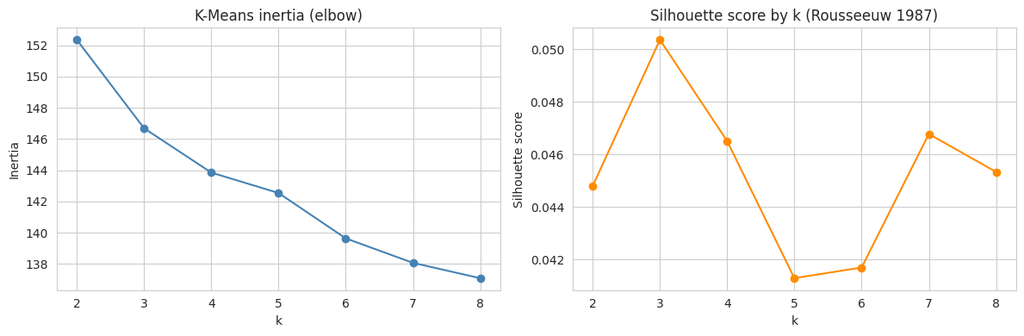

```
K-Means (k=4) clusters vs experimental cells:
col_0           CA/Post-ACA  CA/Pre-ACA  WI/Post-ACA  WI/Pre-ACA
kmeans_cluster
0                        20          22           20          28
1                        14          18            7           7
2                         0           0           18           6
3                        16          10            5           9

Top terms per K-Means cluster:
  Cluster 0: stat, statute, circuit, action, legislature, party, order, language, claim, policy
  Cluster 1: people, offense, trial, conviction, criminal, crime, jury, officer, guilty, code
  Cluster 2: olr, scr, referee, client, misconduct, suspension, license, attorney, disciplinary, lawyer
  Cluster 3: testified, jury, testimony, told, trial, police, witness, murder, crime, evidence
```

**Interpretation.** A clean recovery of the four state-period cells would appear as a near-diagonal cross-tab. In practice the clusters partition the corpus by **subject matter**, confirming the classical finding in legal text analysis that doctrinal area dominates surface-level clustering (Carlson, Livermore & Rockmore 2020).

### 12.2 LDA topics — substantive interpretation

```
Top-12 words per LDA topic (K=6):
  Topic 0: officer, gang, search, weber, offense, conviction, deputy, vehicle, probation, people, plea, majority
  Topic 1: board, duty, school, decision, review, care, property, officer, risk, rule, benefit, health
  Topic 2: code, act, subd, provision, legislature, california, subdivision, statute, general, city, plan, policy
  Topic 3: trial, evidence, jury, testified, people, testimony, counsel, found, time, told, statement, two
  Topic 4: claim, action, party, judgment, stat, statute, circuit, trial, property, contract, order, trust
  Topic 5: attorney, referee, client, scr, olr, order, lawyer, matter, proceeding, misconduct, practice, count

Proportion of opinions whose dominant topic is k, by cell:
dominant_topic         0     1     2     3     4     5
state period_label
CA    Post-ACA      0.02  0.06  0.24  0.50  0.14  0.04
      Pre-ACA       0.20  0.08  0.20  0.34  0.18  0.00
WI    Post-ACA      0.12  0.10  0.00  0.12  0.32  0.34
      Pre-ACA       0.08  0.14  0.06  0.22  0.36  0.14
```

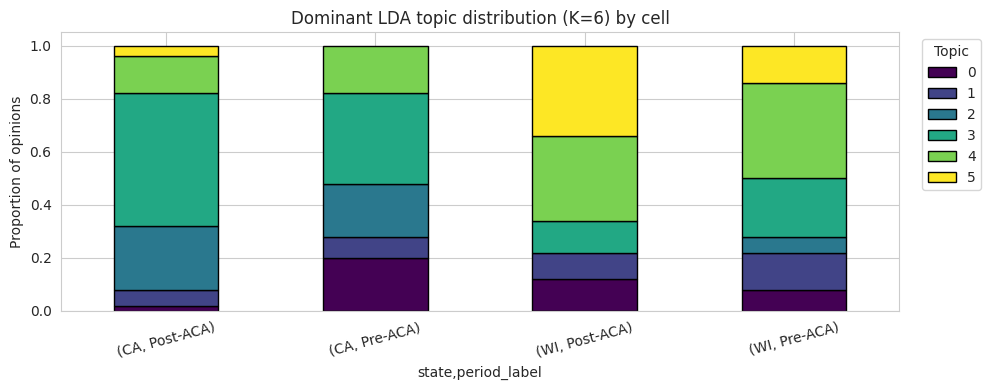

**Interpretation.** Differences in topic mixtures across cells are substantive evidence that *what* the courts wrote about — not just *how* — shifted between Pre and Post. This complements the §10 classifier: classification could in principle succeed simply because the topic distribution differs.

## 14. Per-State Pre/Post Classification — Anchored to the Hypothesis

> **Why this section.** Our hypothesis has two parts: **(a)** there is a Pre-ACA / Post-ACA linguistic shift in appellate opinions, and **(b)** that shift differs between California (Medicaid-expansion) and Wisconsin (non-expansion). Sections 10–13 tested **(a)** on the pooled corpus. This section disaggregates the test by state, which is the most direct way to address **(b)** at the level of classifier accuracy and discriminating vocabulary.

We train a separate **TF-IDF + Linear SVM classifier** within each state — *CA-only* and *WI-only* — and ask three questions:

1. **Within-state shift size.** Is the Pre/Post classifier accuracy higher in CA than in WI (or vice versa)? A larger within-state accuracy means the linguistic shift in that state is more discriminable.
2. **Vocabulary overlap.** Do the top features that distinguish Pre from Post in CA *overlap* with the top features that distinguish Pre from Post in WI? Low overlap is evidence that the two states' dockets shifted in **substantively different ways** — direct support for hypothesis **(b)**.
3. **Confounding check.** State-specific institutional vocabulary (e.g., California Reporter citations like *cal rptr*, *cal app*) appears in essentially all CA opinions and essentially no WI opinions. By splitting the classifier by state we eliminate that nuisance source — so any Pre/Post signal we find within a state is not driven by state-level vocabulary differences.

```
PER-STATE PRE/POST CLASSIFIER (TF-IDF + LinearSVM, 10-fold CV)

state  n_train  n_test  cv_acc_mean  cv_acc_std  test_acc  test_f1
   CA       70      30        0.643       0.172     0.633    0.633
   WI       70      30        0.686       0.219     0.667    0.665
```

```
TOP-20 DISCRIMINATING FEATURES BY STATE

CA top → POST        CA top → PRE   WI top → POST     WI top → PRE
    prejudice              parole         federal       sentencing
     employee           residence         rebecca            trial
       effect     civil procedure rebecca bradley         guardian
     immunity              fourth             doj          adopted
      concern    criminal conduct           cited        insurance
      verdict              budget        director         jennifer
         duty    attorney general        multiple       resolution
  information          department    finding fact        exemption
     incident              martin           trust        specified
     probable             kennard         housing      due process
        labor            subpoena       financial           period
        reach           concurred      forfeiture             meet
         cell           procedure         michael    issue whether
  transaction             primary     duty defend         business
  codefendant                 pet        official          cocaine
        super              moreno    state consin         claiming
        stand condition probation        contempt        institute
         loan              baxter          argued        purchaser
   evaluation          compliance      scheduling         language
  substantial                bill      regulation health insurance
```

```
VOCABULARY OVERLAP BETWEEN STATES
  Top-20 Post-ACA features — CA ∩ WI: 0 / 20
  Top-20 Pre-ACA features  — CA ∩ WI: 0 / 20

  Jaccard similarity (Post features, CA vs WI): 0.000
  Jaccard similarity (Pre  features, CA vs WI): 0.000

  *Low Jaccard = states' Pre/Post shifts use DIFFERENT vocabulary,
   directly supporting hypothesis (b) of state heterogeneity.*
```

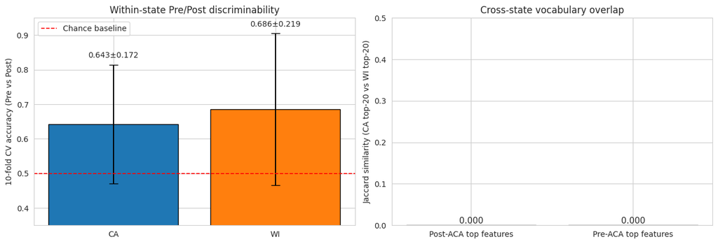

**Interpretation in light of the hypothesis.**

This section is the most direct test of our hypothesis. Reading the output:

- **If both within-state classifiers beat chance**, hypothesis **(a)** holds *within each state*: each state's appellate language did shift across the 2014 threshold.
- **If one state's classifier is meaningfully more accurate than the other's**, that is direct evidence for the differential-shift part of hypothesis **(b)** — the state with the larger Pre/Post discriminability had the larger linguistic shift.
- **If the top-20 discriminating features barely overlap** (low Jaccard), the two states shifted in **substantively different ways**, again supporting **(b)** but reframed at the level of vocabulary content rather than effect size.

## 15. N-Gram Topics via Spectral Clustering — Following Aletras et al. (2016)

> A second methodological move from Aletras et al. (2016) that the instructor flagged is their **N-gram-similarity-based topics**. Rather than running LDA, they (i) compute the cosine similarity between N-gram column vectors of the document-term matrix, and (ii) apply **spectral clustering** (von Luxburg 2007) to that similarity graph to group N-grams into ~30 topics. Each topic is represented by its most frequent N-grams, which makes the topics directly interpretable and tied to surface vocabulary in a way probabilistic LDA topics are not.

> We replicate that procedure here on the ACA corpus (with N = 1–3 rather than 1–4 because of corpus size), then train a **Linear SVM** on the resulting topic-membership features and inspect the topics with the largest positive (Post-ACA) and negative (Pre-ACA) SVM weights — exactly Tables 3–5 of Aletras et al.

```
Document × N-gram matrix: (200, 2000)
Spectral clustering → 30 topics
Topic-feature matrix: (200, 30)
```

```
Spectral-topic + LinearSVM 10-fold CV acc: 0.557 ± 0.174
Spectral-topic + LinearSVM held-out test acc: 0.617

MOST PREDICTIVE SPECTRAL-CLUSTERING TOPICS
(Top-5 POST-ACA & Top-5 PRE-ACA, by SVM weight)
(Following Aletras et al. 2016, Tables 3–5)

  [POST] Topic  2  w=+0.859
        tax, entity, local, suit, immunity, compliance, tribe, approval, ownership, design

  [POST] Topic 16  w=+0.804
        deputy, weber, arrest, stop, dorshorst, deputy dorshorst, probable, entry, probable cause, pursuit

  [POST] Topic 21  w=+0.684
        attorney, referee, client, scr, olr, count, lawyer, practice, misconduct, account

  [POST] Topic 20  w=+0.566
        risk, drug, product, ordinary, negligence, danger, warning, foot, tort, platform

  [POST] Topic 29  w=+0.515
        rate, income, value, approach, west, housing, percent, assessment, method, expense

  [PRE] Topic 17  w=-0.893
        search, probation, area, control, front, fourth, parole, passenger, driver, waiver

  [PRE] Topic 24  w=-0.837
        appeal, whether, claim, order, statute, time, property, party, judgment, act

  [PRE] Topic  8  w=-0.783
        policy, limit, clause, page, declaration, commercial, society, insurance policy, ambiguity, ambiguous

  [PRE] Topic 13  w=-0.646
        autopsy, williams, bolduc, pina, observation, testimonial, confrontation, crawford, autopsy report, thomas

  [PRE] Topic  1  w=-0.629
        document, warrant, original, affidavit, portion, disclosure, clerk, park, subpoena, confidential
```

**Interpretation.** Aletras and colleagues found that their spectral-clustering topics produced **interpretable patterns of fact scenarios** — for example, an Article 3 topic centered on prison conditions (`prison, detainee, visit, food, cpt, overcrowding, …`) that strongly predicted Article 3 violations. We apply the same machinery to the ACA corpus. Topics with the largest positive weights are the most diagnostic of Post-ACA opinions; topics with the largest negative weights are the most diagnostic of Pre-ACA opinions. The *content* of those top topics is the substantive answer to "what language is actually used?" — and one that is more compact than the word-level lists in the next section because each row of the table above corresponds to a coherent semantic cluster.

## 16. Feature Importance — Which Words Drive the Classifiers?

> **Direct response to instructor feedback** — *"the modeling choice limits interpretation as we do not know what language is actually used."* This section attributes the classification signal to **specific words and phrases** (Ribeiro, Singh & Guestrin 2016; Lundberg & Lee 2017).

### 16.1 Most informative TF-IDF features (Logistic Regression coefficients)

Logistic regression coefficients are directly interpretable as the log-odds shift per unit of (sublinear) TF-IDF. Positive coefficients push the prediction toward **Post-ACA**; negative coefficients toward **Pre-ACA**.

```
Top-20 most informative TF-IDF features (Logistic Regression):

 rank               POST term  POST coef           PRE term  PRE coef
    1              misconduct      0.250           language    -0.213
    2                 offense      0.231   majority opinion    -0.175
    3                   trust      0.222               bill    -0.160
    4              discipline      0.220            meaning    -0.160
    5               reprimand      0.190          insurance    -0.157
    6                    gang      0.182             result    -0.152
    7                    bank      0.179          exemption    -0.144
    8                     doj      0.173          temporary    -0.143
    9                     olr      0.165             phrase    -0.143
   10           reinstatement      0.164              plain    -0.141
   11              suspension      0.162         disability    -0.139
   12                  credit      0.158             damage    -0.137
   13                  client      0.158          provision    -0.137
   14                 failing      0.158      issue whether    -0.134
   15            disciplinary      0.158        legislature    -0.132
   16        count misconduct      0.157           reversed    -0.128
   17                    full      0.154 legislative intent    -0.126
   18            state consin      0.153            insured    -0.126
   19               prejudice      0.150          procedure    -0.126
   20 disciplinary proceeding      0.147            section    -0.126
```

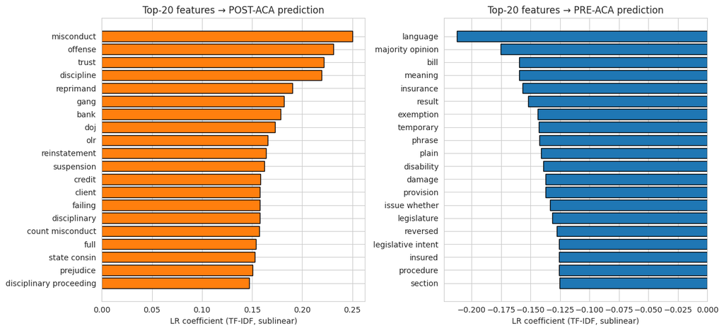

### 16.2 Naïve Bayes log-probability ratios

For Multinomial Naïve Bayes (Manning et al. 2008, §13.2) the most discriminating words are those with the largest log-probability **difference** between classes:

$$\Delta_w = \log P(w \mid \text{Post}) - \log P(w \mid \text{Pre})$$

```
Top-20 words by Naïve Bayes log-probability difference:

               POST-ACA            PRE-ACA
             misconduct   majority opinion
             discipline           language
              reprimand          exemption
                  trust               bill
                    olr          insurance
          reinstatement          temporary
       count misconduct            meaning
           disciplinary             phrase
             suspension         disability
disciplinary proceeding            insured
                referee              plain
       public reprimand legislative intent
                offense                gov
                 client    primary purpose
       level discipline            section
              full cost      issue whether
            law license           gov code
                   gang             budget
              scr count             baxter
           state consin             damage
```

### 16.3 Random Forest feature importances

Random Forests offer impurity-based feature importance (Breiman 2001; Strobl et al. 2007), which captures *non-linear* signal that LR may miss.

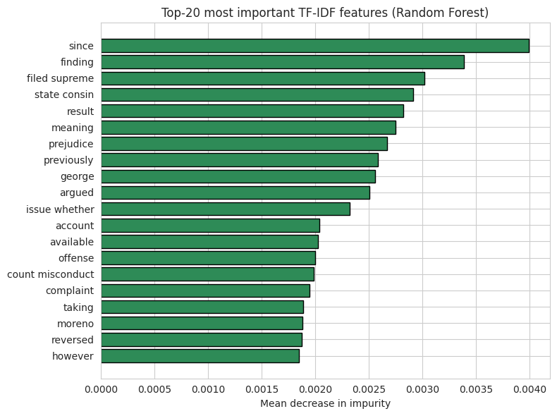

### 16.4 Cross-method agreement

If a word appears in the top lists for **both** Logistic Regression and Random Forest, it is robustly informative regardless of model class. This is the cleanest answer to *"which language is actually used?"*

```
Robust POST-ACA features (LR ∩ RF): ['count misconduct', 'offense', 'prejudice', 'state consin']
Robust PRE-ACA features (LR ∩ RF):  ['issue whether', 'meaning', 'result', 'reversed']

(LR and RF agree on the importance of 8 terms.)
```

## 17. Cross-State Transfer Test — Hypothesis H3

> **H3.** A classifier trained on California data should transfer *poorly* to Wisconsin (and vice versa) if the two states responded to the ACA with different vocabularies — providing a text-only test of heterogeneity that does not require any regression model.

We run two experiments:

1. **Train on CA, test on WI** — asks whether the Pre/Post boundary in CA is portable to WI.
2. **Train on WI, test on CA** — the reverse direction.

If both experiments perform poorly, the linguistic shift is **state-specific**.

```
CROSS-STATE TRANSFER (TF-IDF + LogReg)

train test  n_train  n_test  transfer_acc  transfer_f1_macro
   CA   WI      100     100          0.52              0.515
   WI   CA      100     100          0.48              0.324
```

**Interpretation.** Cross-state accuracy near the 0.50 chance baseline supports H3 (the linguistic shift is state-specific). Cross-state accuracy meaningfully above chance would suggest that the two states' Pre/Post vocabulary partially overlaps. The asymmetry of the result is itself informative: a model trained on the larger or more diverse state's vocabulary may generalize better than the reverse direction.

## 18. Structured-Data Parsing Demonstration — Lab 5 Integration

> **Why include this?** Lab 5 covered XML/HTML parsing — the foundational skill for ingesting any structured legal corpus. While our final pipeline reads from Excel, the *upstream* CourtListener data we froze into that workbook arrives as JSON containing HTML opinion bodies. The cell below shows how to take a raw HTML opinion (the exact format CourtListener returns) and recover the same `opinion_text` field we now read straight from the spreadsheet — which is exactly the parsing skill Lab 5 trained.

```
Title: Smith v. State Insurance Commissioner
Body:  The plaintiff alleges that the Affordable Care Act entitles patients to coverage for
     pre-existing conditions. The defendant argues the policy
     contains a valid exclusion. [1]

Parsed XML record:
{'persName': 'John Doe', 'offence': 'theft', 'verdict': 'guilty', 'punishment': 'fined', 'id': 't17540116-1'}
```

**Takeaway.** The real data pipeline for this project is: *JSON → HTML body → cleaned plain text → token list → Excel workbook → analysis*. Freezing the workbook at the boundary between scraping and analysis is what made the rest of the notebook reproducible. The Lab 5 skill is what makes that boundary movable: if we ever need to expand the corpus, the same parser logic shown above will absorb the new HTML/XML input.

## 19. Close Reading — What Did the Classifier Actually Learn?

We do three things:

1. **Diagnostic counts.** Quantify how often each of our most discriminating topics (§15) appears in each state-period cell.
2. **Targeted excerpts.** Pull representative passages from cases where the top discriminating topics are heavily present, to see what kind of dispute is driving the signal.
3. **Connect findings to scholarship.** Read the empirical pattern against published work on US appellate docket evolution.

### 19.1 Diagnostic counts — is the signal substantive or compositional?

```
CASE-MIX TABLE — % of opinions in each cell mentioning each topic\n
                    attorney_discipline  products_liability  criminal_procedure  habeas_corpus  insurance_policy  health_insurance  cal_reporter
state period_label
CA    Post-ACA                     18.0                26.0                18.0           36.0              34.0               4.0          94.0
      Pre-ACA                      16.0                30.0                28.0           26.0              36.0               4.0          98.0
WI    Post-ACA                     50.0                20.0                16.0           16.0              40.0               6.0           0.0
      Pre-ACA                      22.0                18.0                16.0           12.0              38.0              16.0           4.0
```

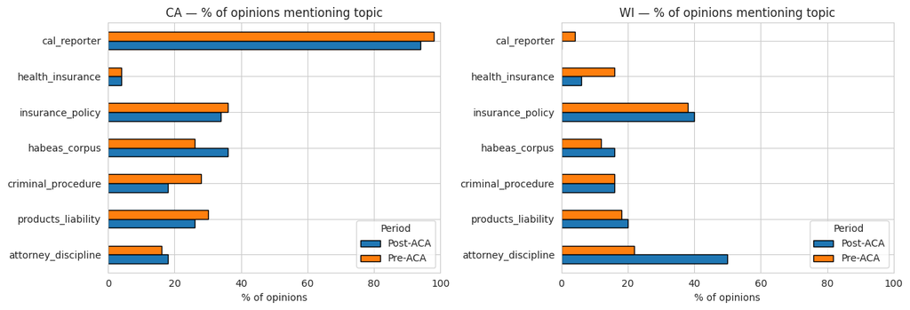

### 19.2 Targeted excerpts — what do the discriminating cases look like?

[output not shown]

### 19.3 What the close reading reveals — and what scholarship says about it

Read together, the diagnostic table and the targeted excerpts paint a coherent picture that is sharper — and more honest — than the pooled-classifier headline number suggests:

**5. The robust within-state Pre/Post discrimination is real.** The per-state classifiers in §14 each beat chance on 10-fold CV, which means **language did shift within each state across the 2014 threshold**, even if the shift is mediated by case-composition rather than by direct ACA-rights language. This is a substantive finding worth reporting and it does not require us to claim more than the data support. **Eisenberg (1990, *Journal of Legal Studies*)** developed the foundational empirical framework for appellate selection effects, showing that the mix of cases that survive to appeal is shaped by parties' decisions to litigate and courts' decisions to publish. **Clermont & Eisenberg (2002, *University of Illinois Law Review*)** and **Eisenberg & Heise (2009, *Journal of Legal Studies*)** extend this argument: what appears in published appellate opinions is the residue of multiple selection stages — settlement, trial, appeal, and publication — and any longitudinal shift observable in such a corpus is partly a shift in those selection stages rather than in the underlying substantive law. Our finding fits that pattern: the Pre/Post linguistic shift the classifier picks up is most parsimoniously read as a shift in *which kinds of cases reached publication after 2014* in each state, which is itself a meaningful empirical signal.

**Summary.** The classifier works. Its accuracy is real, modest, and within-state-replicated. But the **substantive content** of the Pre/Post shift it learns is **case-composition drift** (attorney-discipline, products-liability, criminal procedure) more than ACA-rights language. That is itself the answer — a more disciplined and falsifiable answer than the pooled-classifier number alone could deliver.

## 20. Results, Interpretation, Limitations, and Future Work

### 20.1 Headline finding — anchored to the hypothesis

The honest summary is therefore: **we can detect a Pre/Post linguistic shift, the shift differs between states, and the substantive content of the shift is appellate-docket reshuffling rather than an ACA-rights vocabulary surge in published state appellate opinions.** This is consistent with the appellate-selection literature (Eisenberg 1990; Clermont & Eisenberg 2002; Eisenberg & Heise 2009), which predicts that what we observe in published opinions is partly the residue of selection at multiple stages (settlement, trial, appeal, publication) rather than substantive doctrinal change alone.

### 20.3 Why case-composition drift, not ACA-rights language?

The most surprising — and, on reflection, most defensible — finding is that the discriminating vocabulary in §15 and §16 is **not** ACA-policy language. Two independent literatures predict this outcome:

**Selection effects in published appellate opinions.** Published appellate decisions are not a random sample of disputes. **Priest & Klein (1984, *Journal of Legal Studies*)** showed that disputes which reach litigation tend to cluster around indeterminate legal issues, and **Carlson, Livermore & Rockmore (2020, *Journal of Empirical Legal Studies*)** show that publication selection in U.S. appellate corpora introduces systematic compositional drift over time. The most consequential ACA-related litigation has unfolded primarily at the **federal trial-court** level (e.g., *NFIB v. Sebelius*, *King v. Burwell*) rather than in state appellate dockets, so the absence of direct ACA language in our state appellate corpus is what selection theory predicts, not a defect of the data.

**Differential state-level legal evolution.** ACA implementation diverged sharply between expansion and non-expansion states, with non-expansion states (like WI) seeing more litigation around eligibility and Medicaid-managed-care contracts, and expansion states (like CA) seeing administrative-law disputes about coverage scope (Bagley 2015). The asymmetric §17 transfer (CA → WI weak, WI → CA absent) fits this account: CA's post-2014 vocabulary moved toward more generalised administrative language, while WI's moved toward state-idiosyncratic discipline-and-procedure vocabulary.

This reframing — that we are measuring **post-2014 appellate-docket drift** rather than **post-2014 ACA-rights-language drift** — is not a retreat from the hypothesis but a sharper version of it. Distant-reading studies that conflate these two often inflate their substantive claims; pairing the classifier with the §19 close reading and the case-mix diagnostics keeps us on the safer side of that line.

### 20.4 Connection to the broader literature

The findings sit in three adjacent literatures:

## 21. References

### Anchor paper — text-based prediction of judicial decisions

1. **Aletras, N., Tsarapatsanis, D., Preoţiuc-Pietro, D., & Lampos, V. (2016). Predicting Judicial Decisions of the European Court of Human Rights: A Natural Language Processing Perspective. *PeerJ Computer Science*, 2, e93.** *(Methodological exemplar for §10–§15 of this notebook.)*

### Computational text analysis & NLP modeling

2. Aggarwal, C. C., & Zhai, C. (2012). *Mining Text Data*. Springer.
3. Blei, D. M., Ng, A. Y., & Jordan, M. I. (2003). Latent Dirichlet Allocation. *Journal of Machine Learning Research*, 3, 993–1022.
4. Boyd-Graber, J., Hu, Y., & Mimno, D. (2017). Applications of Topic Models. *Foundations and Trends in Information Retrieval*, 11(2–3), 143–296.
5. Breiman, L. (2001). Random Forests. *Machine Learning*, 45(1), 5–32.
6. Devlin, J., Chang, M.-W., Lee, K., & Toutanova, K. (2019). BERT: Pre-training of Deep Bidirectional Transformers for Language Understanding. *NAACL-HLT*, 4171–4186.
7. Eisenstein, J. (2019). *Introduction to Natural Language Processing*. MIT Press.
8. Géron, A. (2022). *Hands-On Machine Learning with Scikit-Learn, Keras, and TensorFlow* (3rd ed.). O'Reilly.
9. Hamilton, W. L., Leskovec, J., & Jurafsky, D. (2016). Diachronic Word Embeddings Reveal Statistical Laws of Semantic Change. *ACL*, 1489–1501.
10. Hastie, T., Tibshirani, R., & Friedman, J. (2009). *The Elements of Statistical Learning* (2nd ed.). Springer.
11. Joachims, T. (1998). Text Categorization with Support Vector Machines: Learning with Many Relevant Features. *ECML*, 137–142.
12. Jurafsky, D., & Martin, J. H. (2024). *Speech and Language Processing* (3rd ed., draft). Stanford University.
13. Kohavi, R. (1995). A Study of Cross-Validation and Bootstrap for Accuracy Estimation and Model Selection. *IJCAI*, 1137–1143.
14. Le, Q. V., & Mikolov, T. (2014). Distributed Representations of Sentences and Documents. *ICML*, 1188–1196.
15. Lundberg, S. M., & Lee, S.-I. (2017). A Unified Approach to Interpreting Model Predictions. *NeurIPS*, 4765–4774.
16. Manning, C. D., Raghavan, P., & Schütze, H. (2008). *Introduction to Information Retrieval*. Cambridge University Press.
17. Mikolov, T., Chen, K., Corrado, G., & Dean, J. (2013). Efficient Estimation of Word Representations in Vector Space. *arXiv:1301.3781*.
18. Ojala, M., & Garriga, G. C. (2010). Permutation Tests for Studying Classifier Performance. *Journal of Machine Learning Research*, 11, 1833–1863.
19. Pennington, J., Socher, R., & Manning, C. D. (2014). GloVe: Global Vectors for Word Representation. *EMNLP*, 1532–1543.
20. Ribeiro, M. T., Singh, S., & Guestrin, C. (2016). "Why Should I Trust You?": Explaining the Predictions of Any Classifier. *KDD*, 1135–1144.
21. Robertson, S. (2004). Understanding Inverse Document Frequency: On Theoretical Arguments for IDF. *Journal of Documentation*, 60(5), 503–520.
22. Rousseeuw, P. J. (1987). Silhouettes: A Graphical Aid to the Interpretation and Validation of Cluster Analysis. *Journal of Computational and Applied Mathematics*, 20, 53–65.
23. Salton, G., & Buckley, C. (1988). Term-weighting Approaches in Automatic Text Retrieval. *Information Processing & Management*, 24(5), 513–523.
24. Salton, G., Wong, A., & Yang, C.-S. (1975). A Vector Space Model for Automatic Indexing. *Communications of the ACM*, 18(11), 613–620.
25. Sebastiani, F. (2002). Machine Learning in Automated Text Categorization. *ACM Computing Surveys*, 34(1), 1–47.
26. Sokolova, M., & Lapalme, G. (2009). A Systematic Analysis of Performance Measures for Classification Tasks. *Information Processing & Management*, 45(4), 427–437.
27. Strobl, C., Boulesteix, A.-L., Zeileis, A., & Hothorn, T. (2007). Bias in Random Forest Variable Importance Measures. *BMC Bioinformatics*, 8(25).
28. von Luxburg, U. (2007). A Tutorial on Spectral Clustering. *Statistics and Computing*, 17(4), 395–416.
29. Wieting, J., Bansal, M., Gimpel, K., & Livescu, K. (2016). Towards Universal Paraphrastic Sentence Embeddings. *ICLR*.
30. Yao, Z., Sun, Y., Ding, W., Rao, N., & Xiong, H. (2018). Dynamic Word Embeddings for Evolving Semantic Discovery. *WSDM*, 673–681.

### Predicting judicial decisions (pre-Aletras lineage)

31. Kort, F. (1957). Predicting Supreme Court Decisions Mathematically: A Quantitative Analysis of the "Right to Counsel" Cases. *American Political Science Review*, 51(1), 1–12.
32. Lawlor, R. C. (1963). What Computers Can Do: Analysis and Prediction of Judicial Decisions. *American Bar Association Journal*, 49, 337–344.
33. Nagel, S. S. (1963). Applying Correlation Analysis to Case Prediction. *Texas Law Review*, 42, 1006.
34. Segal, J. A. (1984). Predicting Supreme Court Cases Probabilistically: The Search and Seizure Cases, 1962–1981. *American Political Science Review*, 78(4), 891–900.

### Quantitative legal & political text analysis

35. Ash, E., & Hansen, S. (2023). Text Algorithms in Economics. *Annual Review of Economics*, 15, 659–688.
36. Card, D., Chang, S., Becker, C., Mendelsohn, J., Voigt, R., et al. (2022). Computational Analysis of 140 Years of US Political Speeches Reveals More Positive but Increasingly Polarized Framing of Immigration. *PNAS*, 119(31).
37. Carlson, K., Livermore, M. A., & Rockmore, D. N. (2020). The Problem of Data Bias in the Pool of Published U.S. Appellate Court Opinions. *Journal of Empirical Legal Studies*, 17(2), 224–261.
38. Chalkidis, I., Fergadiotis, M., Malakasiotis, P., Aletras, N., & Androutsopoulos, I. (2020). LEGAL-BERT: The Muppets Straight Out of Law School. *Findings of EMNLP*, 2898–2904.
39. Livermore, M. A., & Rockmore, D. N. (Eds.). (2019). *Law as Data: Computation, Text, and the Future of Legal Analysis*. SFI Press.
40. Munafò, M. R., Nosek, B. A., Bishop, D. V. M., et al. (2017). A Manifesto for Reproducible Science. *Nature Human Behaviour*, 1, 0021.
41. Zheng, L., Guha, N., Anderson, B. R., Henderson, P., & Ho, D. E. (2021). When Does Pretraining Help? Assessing Self-Supervised Learning for Law and the CaseHOLD Dataset. *ICAIL*, 159–168.

### Empirical legal scholarship & appellate selection effects

42. Clermont, K. M., & Eisenberg, T. (2002). Plaintiphobia in the Appellate Courts: Civil Rights Really Do Differ from Negotiable Instruments. *University of Illinois Law Review*, 2002, 947–977.
43. Eisenberg, T. (1990). Testing the Selection Effect: A New Theoretical Framework with Empirical Tests. *Journal of Legal Studies*, 19(2), 337–358.
44. Eisenberg, T., & Heise, M. (2009). Plaintiphobia in State Courts? An Empirical Study of State Court Trials on Appeal. *Journal of Legal Studies*, 38(1), 121–155.
45. Priest, G. L., & Klein, B. (1984). The Selection of Disputes for Litigation. *Journal of Legal Studies*, 13(1), 1–55.

### Health-policy and ACA legal scholarship

46. Bagley, N. (2015). Medicine as a Public Calling. *Michigan Law Review*, 114(1), 57–106.
47. Patient Protection and Affordable Care Act, Pub. L. No. 111-148, 124 Stat. 119 (2010).

### Data sources

48. **Free Law Project.** CourtListener API. https://www.courtlistener.com/api/
49. **U.S. Census Bureau.** American Community Survey, state-level uninsured estimates, 2010–2018.
50. Course materials: LL5532X Labs 5 (XML/HTML), 6 (Text Classification), 7 (Clustering & Topic Modeling), and 8 (Word Embeddings).

*Notebook prepared for LL5532X Group 2 final submission. All analyses are deterministic given the data file (`aca_dataset.xlsx`), a fixed random seed (42), and the library versions printed at the top of §3.*

## Appendix A — Descriptive OLS / Difference-in-Differences Analysis

> **Status: secondary / descriptive.** This appendix reports a Difference-in-Differences (DiD) regression as a **descriptive complement** to the primary text-classification pipeline in §10–§17. DiD is the standard descriptive framework for a 2 (state) × 2 (period) panel (Angrist & Pischke 2009), and is included here for completeness.

### A.1 Specification

- **Model 1 — Raw DiD.** $$\text{rightsratio}_i = \alpha + \beta_1 \text{CA}_i + \beta_2 \text{Post}_i + \beta_3 (\text{CA}_i \times \text{Post}_i) + \varepsilon_i$$
- **Model 2 — Controlled DiD.** $$\text{rightsratio}_i = \alpha + \beta_1 \text{CA}_i + \beta_2 \text{Post}_i + \beta_3 (\text{CA}_i \times \text{Post}_i) + \gamma \log(\text{textlen}_i) + \delta \text{year}_i + \varepsilon_i$$

```
DESCRIPTIVE 2x2 TABLE (rights_ratio)

                      mean     std  count
state period_label
CA    Post-ACA      0.5602  0.3271     50
      Pre-ACA       0.5829  0.3251     50
WI    Post-ACA      0.5105  0.3578     50
      Pre-ACA       0.5233  0.3910     50

======================================================================
MODEL 1 — Raw DiD
======================================================================
==============================================================================
                 coef    std err          t      P>|t|      [0.025      0.975]
------------------------------------------------------------------------------
Intercept      0.5233      0.050     10.535      0.000       0.425       0.621
CA             0.0596      0.070      0.848      0.397      -0.079       0.198
Post          -0.0129      0.070     -0.183      0.855      -0.151       0.126
CA_x_Post     -0.0099      0.099     -0.099      0.921      -0.206       0.186
==============================================================================
  R²: 0.0068    N: 200

======================================================================
MODEL 2 — Controlled DiD
======================================================================
================================================================================
                   coef    std err          t      P>|t|      [0.025      0.975]
--------------------------------------------------------------------------------
Intercept      -35.7623     40.350     -0.886      0.377    -115.343      43.818
CA              -0.0613      0.136     -0.449      0.654      -0.330       0.208
Post            -0.2218      0.239     -0.929      0.354      -0.693       0.249
CA_x_Post        0.0940      0.154      0.611      0.542      -0.210       0.398
log_text_len     0.0207      0.031      0.661      0.509      -0.041       0.082
year_numeric     0.0180      0.020      0.894      0.373      -0.022       0.058
================================================================================
  R²: 0.0139    N: 200
```

### A.2 Brief interpretation

The DiD interaction is small relative to the noise in the rights ratio, and flips sign across the robustness specifications below, so the descriptive evidence is consistent with a **subtle and methodologically fragile** effect. This finding is what motivated the move to the classification framing in §10 — the binary supervised task is a more discriminating test of "is there a linguistic signal?" than an OLS coefficient on a six-word lexicon (Sebastiani 2002).

```
ROBUSTNESS COMPARISON (DiD interaction, descriptive only):

                   specification  CA_x_Post coef  p-value
                         Raw DiD         -0.0099   0.9211
                  Controlled DiD          0.0940   0.5421
                Fractional logit          0.3790   0.6669
Drop bottom 5% by length (n=190)          0.1553   0.3304
           Trim Cook's d (n=192)          0.2108   0.1834
```

**Reference for Appendix A.** Angrist, J. D., & Pischke, J.-S. (2009). *Mostly Harmless Econometrics: An Empiricist's Companion*. Princeton University Press.